# 13_output_feedback

## 3.3. PID Control

The derivative of the process error is calculated by determining the slope of the error over time and multiplying this rate of change by the derivative gain $k_D$.

Derivative action predicts system behavior and thus improves settling time and stability of the system. The implementations of D controllers include an additional low-pass filtering for the derivative term to limit the high-frequency gain and noise. Derivative action is seldom used in practice though because of its variable impact on system stability in real-world applications.

$$ u(t) = k_P \, e(t) + k_I \int_0^t e(\tau)d\tau + k_D \frac{d e(t)}{d t}$$

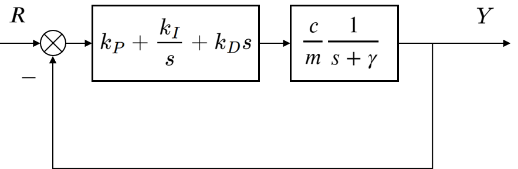

PID: by far the most used low-level controller

- P: contributes to stability, medium-rate responsiveness
- I: tracking and disturbance rejection, slow-rate responsive, may cause oscillations
- D: fast-rate responsiveness, sensitive to noise

Feedback has a remarkable ability to fight uncertainty in model parameters !

The goal of this problem is to show how each of the term, $k_P, k_I$ and $k_D$ contributes to obtaining the common goals of:

- Fast rise time
- Minimal overshot
- Zero steady-state error

$k_P = 1,k_I = 0, k_D = 0$

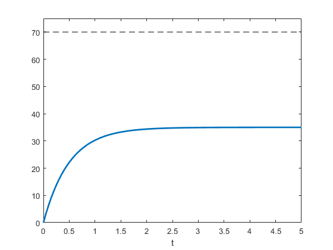

```matlab
Gtr = tf(c/m,[1 gamma]);

kP = 1;
kI = 0;
kD = 0;
C = tf([kD kP kI],[1 0]);

Gcl = feedback(C*Gtr,1,-1);

x0 = 0;
t = linspace(0,5,100);
r = 70*ones(size(t));

[y,tout] = lsim(Gcl,r,t,x0);

plot(tout,y, 'linewidth', 2), hold on
plot(tout,70*ones(size(tout)),'--k'), hold off
xlabel('t'), ylim([0,75])
```

$k_P = 1, k_I = 1, k_D = 0$

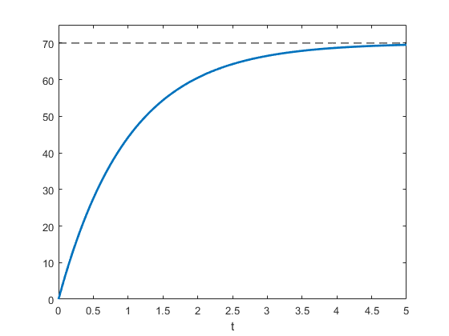

```matlab
Gtr = tf(c/m,[1 gamma]);

kP = 1;
kI = 1;
kD = 0;
C = tf([kD kP kI],[1 0]);

Gcl = feedback(C*Gtr,1,-1);

x0 = 0;
t = linspace(0,5,100);
r = 70*ones(size(t));

[y,tout] = lsim(Gcl,r,t,x0);

plot(tout,y, 'linewidth', 2), hold on
plot(tout,70*ones(size(tout)),'--k'), hold off
xlabel('t'), ylim([0,75])
```

$k_P = 1, k_I = 10, k_D = 0$

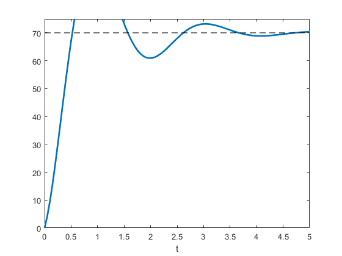

```matlab
Gtr = tf(c/m,[1 gamma]);

kP = 1;
kI = 10;
kD = 0;
C = tf([kD kP kI],[1 0]);

Gcl = feedback(C*Gtr,1,-1);

x0 = 0;
t = linspace(0,5,100);
r = 70*ones(size(t));

[y,tout] = lsim(Gcl,r,t,x0);

plot(tout,y, 'linewidth', 2), hold on
plot(tout,70*ones(size(tout)),'--k'), hold off
xlabel('t'), ylim([0,75])
```

$k_P = 1, k_I = 2, k_D = 0.1$

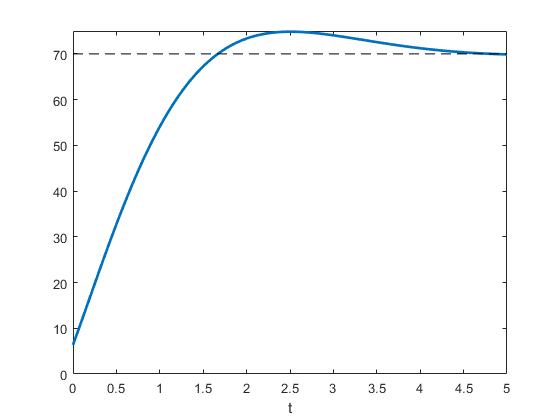

```matlab
Gtr = tf(c/m,[1 gamma]);

kP = 1;
kI = 2;
kD = 0.1;
C = tf([kD kP kI],[1 0]);

Gcl = feedback(C*Gtr,1,-1);

x0 = 0;
t = linspace(0,5,100);
r = 70*ones(size(t));

[y,tout] = lsim(Gcl,r,t,x0);

plot(tout,y, 'linewidth', 2), hold on
plot(tout,70*ones(size(tout)),'--k'), hold off
xlabel('t'), ylim([0,75])
```

**Another Example**

$$G(s) = \frac{1}{s^2 + 10s + 20}$$

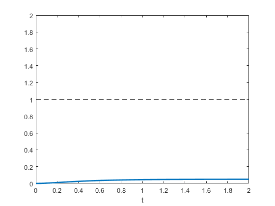

```matlab
s = tf('s');
G = 1/(s^2 + 10*s + 20);

x0 = 0;
t = linspace(0,2,100);
r = 1*ones(size(t));

[y,tout] = lsim(G,r,t,x0);

plot(tout,y, 'linewidth', 2), hold on
plot(tout,1*ones(size(tout)),'--k'), hold off
xlabel('t'), ylim([0,2])
```

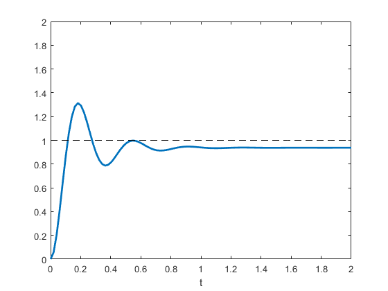

```matlab
kP = 300;
C = pid(kP,0,0);
Gcl = feedback(C*G,1,-1);

x0 = 0;
t = linspace(0,2,100);
r = 1*ones(size(t));

[y,tout] = lsim(Gcl,r,t,x0);

plot(tout,y, 'linewidth', 2), hold on
plot(tout,1*ones(size(tout)),'--k'), hold off
xlabel('t'), ylim([0,2])
```

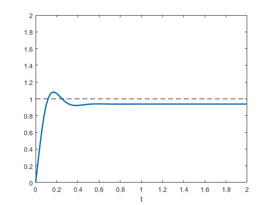

```matlab
kP = 300;
kD = 10;
C = pid(kP,0,kD);
Gcl = feedback(C*G,1,-1);

x0 = 0;
t = linspace(0,2,100);
r = 1*ones(size(t));

[y,tout] = lsim(Gcl,r,t,x0);

plot(tout,y, 'linewidth', 2), hold on
plot(tout,1*ones(size(tout)),'--k'), hold off
xlabel('t'), ylim([0,2])
```

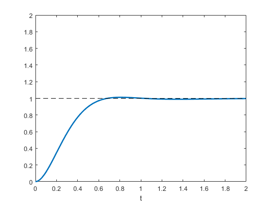

```matlab
kP = 30;
kI = 70;
C = pid(kP,kI);
Gcl = feedback(C*G,1);

x0 = 0;
t = linspace(0,2,100);
r = 1*ones(size(t));

[y,tout] = lsim(Gcl,r,t,x0);

plot(tout,y, 'linewidth', 2), hold on
plot(tout,1*ones(size(tout)),'--k'), hold off
xlabel('t'), ylim([0,2])
```

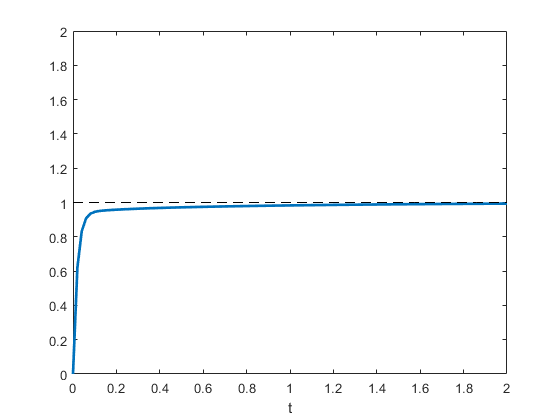

```matlab
kP = 350;
kI = 300;
kD = 50;
C = pid(kP,kI,kD);
Gcl = feedback(C*G,1,-1);

x0 = 0;
t = linspace(0,2,100);
r = 1*ones(size(t));

[y,tout] = lsim(Gcl,r,t,x0);

plot(tout,y, 'linewidth', 2), hold on
plot(tout,1*ones(size(tout)),'--k'), hold off
xlabel('t'), ylim([0,2])
```

## 3.4. General Tips for Designing a PID Controller

When you are designing a PID controller for a given system, follow the steps shown below to obtain a desired response.

- Obtain an open-loop response and determine what needs to be improved
- Add a proportional control to improve the rise time
- Add a derivative control to reduce the overshoot
- Add an integral control to reduce the steady-state error
- Adjust each of the gains $k_P$, $k_I$, and $k_D$ until you obtain a desired overall response.

Lastly, please keep in mind that you do not need to implement all three controllers (proportional, derivative, and integral) into a single system, if not necessary. For example, if a PI controller meets the given requirements (like the above example), then you don't need to implement a derivative controller on the system. Keep the controller as simple as possible.

# 4. MKC System as Closed Loop

- mass

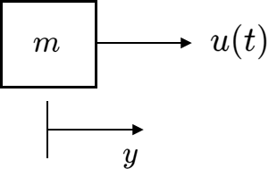

$$m\ddot{y} = u$$

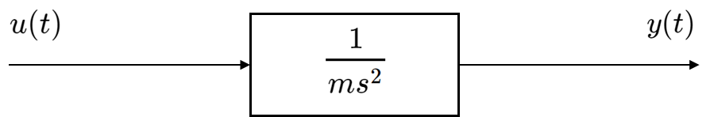

- mass and spring

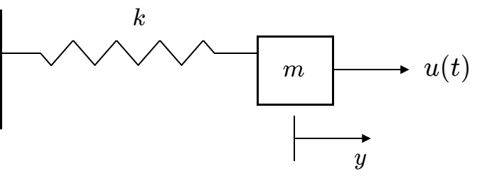

$$m\ddot{y} + ky= u$$

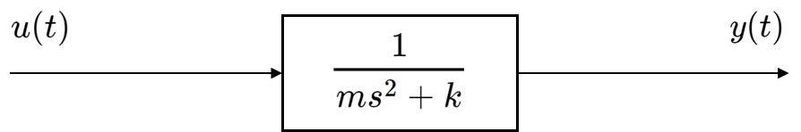

$$m\ddot{y} = u - ky$$

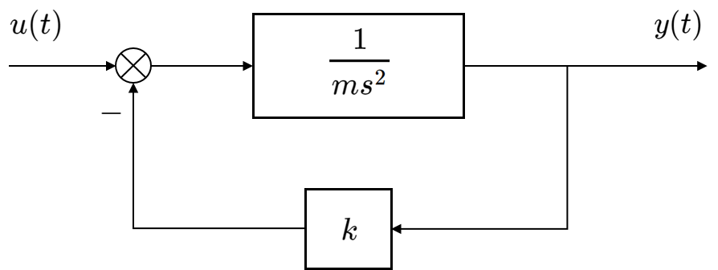

- mass, spring and damper

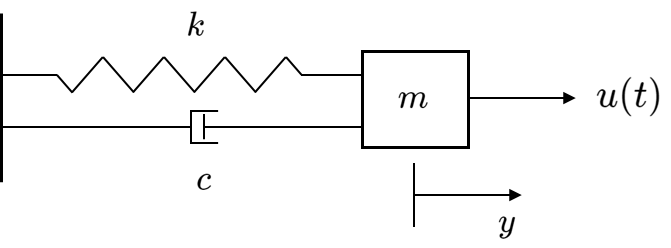

$$m\ddot{y} + c\dot{y} + ky= u$$

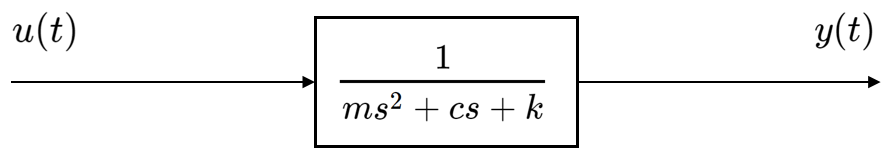

$$m\ddot{y} = u - ky - c\dot{y}$$

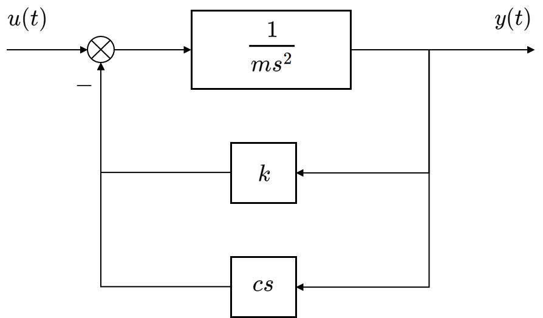

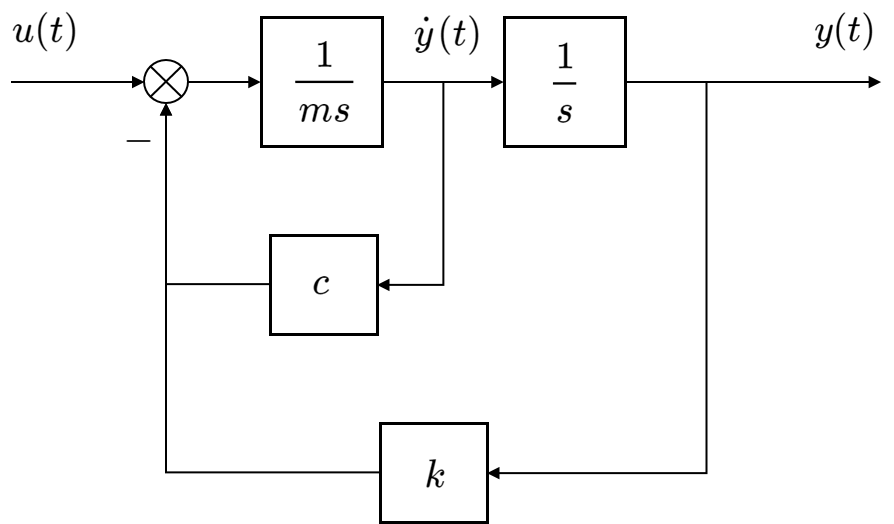

# 5. Other Tutorials

```matlab
%%html
<center><iframe src="https://www.youtube.com/embed/-fNoz5K5FHA?rel=0"
width="560" height="315" frameborder="0" allowfullscreen></iframe></center>
```

[video not shown]

```matlab
%%html
<center><iframe src="https://www.youtube.com/embed/DJuo9kLdr4M?list=PLp8ijpvp8iCvFDYdcXqqYU5Ibl_aOqwjr?rel=0"
width="560" height="315" frameborder="0" allowfullscreen></iframe></center>
```

[video not shown]

```matlab
%%html
<center><iframe src="https://www.youtube.com/embed/cQhqx65kLfM?list=PLp8ijpvp8iCvFDYdcXqqYU5Ibl_aOqwjr?rel=0"
width="560" height="315" frameborder="0" allowfullscreen></iframe></center>
```

[video not shown]

```matlab
%%html
<center><iframe src="https://www.youtube.com/embed/Mk1ygHj4zxw?list=PLp8ijpvp8iCvFDYdcXqqYU5Ibl_aOqwjr?rel=0"
width="560" height="315" frameborder="0" allowfullscreen></iframe></center>
```

[video not shown]

```matlab
%%html
<center><iframe src="https://www.youtube.com/embed/UR0hOmjaHp0?rel=0"
width="560" height="315" frameborder="0" allowfullscreen></iframe></center>
```

[video not shown]

```matlab
%%html
<center><iframe src="https://www.youtube.com/embed/XfAt6hNV8XM?rel=0"
width="560" height="315" frameborder="0" allowfullscreen></iframe></center>
```

[video not shown]

```matlab
%%javascript
$.getScript('https://kmahelona.github.io/ipython_notebook_goodies/ipython_notebook_toc.js')
```